# MachineLearningQuestions

1) What’s the difference between AI, ML and DL?

```python
from IPython.display import Image
from IPython.core.display import HTML
Image(url= "https://sonix.ai/packs/media/images/corp/articles/classification-of-ai-ml-dl-44838b636b886c49760da4ab7f6b6fa4.jpg")
```

[figure not shown]

**AI:**  
AI is incorporating human intelligence to machines. Whenever a machine completes tasks based on a set of rules that solve problems (algorithms), such an “intelligent” behaviour is what is called artificial intelligence.

**ML:**  
ML is to enable machines to learn by themselves using the provided data and make accurate predictions. It is a method of training algorithms such that they can learn how to make decisions. And, a machine learning algorithm can be developed to try to identify whether the fruit is an orange or an apple. After the algorithm is fed with the training data, it will learn the differing characteristics between an orange and an apple. Therefore, if provided with data of weight and texture, it can predict accurately the type of fruit with those characteristics.

**DL:**  
In other words, DL is the next evolution of machine learning. DL algorithms are roughly inspired by the information processing patterns found in the human brain. Just like we use our brains to identify patterns and classify various types of information, deep learning algorithms can be taught to accomplish the same tasks for machines.

2) What is supervised learning?

Supervised learning is where you have input variables (x) and an output variable (Y) and you use an algorithm to learn the mapping function from the input to the output.

$Y = f(X)$

The goal is to approximate the mapping function so well that when you have new input data (x) that you can predict the output variables (Y) for that data.

Supervised learning problems can be further grouped into regression and classification problems.

- Classification: A classification problem is when the output variable is a category, such as “red” or “blue” or “disease” and “no disease”.
- Regression: A regression problem is when the output variable is a real value, such as “dollars” or “weight”.

3) What is unsupervised learning?

Unsupervised learning is where you only have input data (X) and no corresponding output variables.

The goal for unsupervised learning is to model the underlying structure or distribution in the data in order to learn more about the data.

These are called unsupervised learning because unlike supervised learning above there is no correct answers and there is no teacher. Algorithms are left to their own devises to discover and present the interesting structure in the data.

Unsupervised learning problems can be further grouped into clustering and association problems.

- Clustering: A clustering problem is where you want to discover the inherent groupings in the data, such as grouping customers by purchasing behavior.
- Association: An association rule learning problem is where you want to discover rules that describe large portions of your data, such as people that buy X also tend to buy Y.

4) Describe the following supervised learning problems in short:

a) Regression

- A regression problem is when the output variable is a real or continuous value, such as “salary” or “weight”. Many different models can be used, the simplest is the linear regression. It tries to fit data with the best hyper-plane which goes through the points.

b) Classification

- A classification problem is when the output variable is a category, such as “red” or “blue” or “disease” and “no disease”. A classification model attempts to draw some conclusion from observed values. Classification models include logistic regression, decision tree, random forest, gradient-boosted tree, multilayer perceptron, one-vs-rest, and Naive Bayes.

c, d, e, f) Localization, Object detection, Semantic segmentation, Instance segmentation

- Classification/Recognition: Given an image with an object , find out what that object is. In other words, classify it in a class from a set of predefined categories.
- Localization : Find where the object is and draw a bounding box around it
- Object detection: Classify and detect all objects in the image. Assign a class to each object and draw a bounding box around it.
- Semantic Segmentation: Classify every pixel in the image to a class according to its context, so that each pixel is assigned to an object
- Instance Segmentation: Classify every pixel in the image to a class so that each pixel is assigned to a different instance of an object

```python
Image(url="https://sergioskar.github.io/assets/img/posts/cv_tasks.jpg")
```

[figure not shown]

g) Clustering

- Clustering is the task of dividing the population or data points into a number of groups such that data points in the same groups are more similar to other data points in the same group and dissimilar to the data points in other groups. It is basically a collection of objects on the basis of similarity and dissimilarity between them.

h) Image captioning

- Image Captioning is the process of generating textual description of an image. It uses both Natural Language Processing and Computer Vision to generate the captions. [link for paper](https://arxiv.org/pdf/1810.04020.pdf)

i) Machine translation

- https://medium.com/@ageitgey/machine-learning-is-fun-part-5-language-translation-with-deep-learning-and-the-magic-of-sequences-2ace0acca0aa

j) Density estimation

- Use statistical models to find an underlying probability distribution that gives rise to the observed variables.
  - Example: Kernel Density Estimation (Theory and Application)
  - Example: Mixture models. Normal (or Gaussian) mixture models are especially popular.

In statistics, kernel density estimation (KDE) is a non-parametric way to estimate the probability density function of a random variable

```python
Image(url="https://wikimedia.org/api/rest_v1/media/math/render/svg/f3b09505158fb06033aabf9b0116c8c07a68bf31")
```

[figure not shown]

5) Linear Regression https://ml-cheatsheet.readthedocs.io/en/latest/linear_regression.html

6) Polinomial Regression https://towardsdatascience.com/introduction-to-linear-regression-and-polynomial-regression-f8adc96f31cb

7, 8) What is Overfitting and Underfitting

- Overfitting occurs when a statistical model or machine learning algorithm captures the noise of the data. Intuitively, overfitting occurs when the model or the algorithm fits the data too well. Specifically, overfitting occurs if the model or algorithm shows low bias but high variance. Overfitting is often a result of an excessively complicated model, and it can be prevented by fitting multiple models and using validation or cross-validation to compare their predictive accuracies on test data.
- Underfitting occurs when a statistical model or machine learning algorithm cannot capture the underlying trend of the data. Intuitively, underfitting occurs when the model or the algorithm does not fit the data well enough. Specifically, underfitting occurs if the model or algorithm shows low variance but high bias. Underfitting is often a result of an excessively simple model.

9) What is Logisitc Regression https://towardsdatascience.com/introduction-to-logistic-regression-66248243c148 https://kambria.io/blog/logistic-regression-for-machine-learning/

10) What do you mean under interpretability? When is it important?

- Interpretability is closely connected with the ability of users to understand the model. Typical criteria are:
  - a small number of input features (only the necessary ones), ideally not more than 2-3 to make a simple visualization possible,
  - features fitting to user's expectation (e.g., based on a priori knowledge that can be formalized as a priori relevance),
  - a simple internal processing, e.g. by understandable rules instead of a complex processing inside an Artificial Neural Network.

11) Define the dense layer and its gradient (with formula).

- A dense layer is a Layer in which Each Input Neuron is connected to the output Neuron, like a Simple neural net, the parameters units just tells you the dimensionnality of your Output

"""  
@tf.custom_gradient  
def log1pexp(x):  
e = tf.exp(x)  
def grad(dy):  
return dy * (1 - 1 / (1 + e))  
return tf.math.log(1 + e), grad  
"""

Gradient Descent:

Given a cost function:  
$f(m,b) = \frac{1}{N} \sum_{i=1}^{n} (y_i - (mx_i + b))^2$

The Gradient can be calculated:

\begin{split}f'(m,b) = \begin{bmatrix} \frac{df}{dm}\\ \frac{df}{db}\\ \end{bmatrix} = \begin{bmatrix} \frac{1}{N} \sum -2x_i(y_i - (mx_i + b)) \\ \frac{1}{N} \sum -2(y_i - (mx_i + b)) \\ \end{bmatrix}\end{split}

12) Why do we need activation functions

- We must use activation functions such as ReLu, sigmoid and tanh in order to add a non-linear property to the neural network. In this way, the network can model more complex relationships and patterns in the data.

13) Define the fully connected neural network (with formula): input, goal, cost function, layers

- https://www.oreilly.com/library/view/tensorflow-for-deep/9781491980446/ch04.html
- http://cs231n.github.io/neural-networks-1/
- https://www.researchgate.net/publication/331525817_Temporal_Convolutional_Neural_Network_for_the_Classification_of_Satellite_Image_Time_Series#pf3
- https://leonardoaraujosantos.gitbooks.io/artificial-inteligence/fc_layer.html

14) What are the partial derivatives?

15) Define the gradient descent algorithm!

model = initialization(...)  
n_epochs = ...  
train_data = ...  
for i in n_epochs:  
train_data = shuffle(train_data)  
X, y = split(train_data)  
predictions = predict(X, model)  
error = calculate_error(y, predictions)  
model = update_model(model, error)

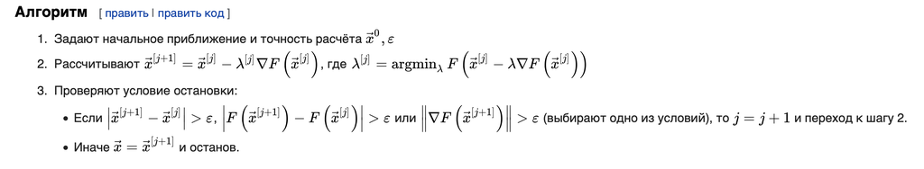

```python
Image("/Users/macbook/Desktop/1.png")
```

16) Define the mini-batch stochastic gradient descent algorithm!

- Batch gradient descent is a variation of the gradient descent algorithm that calculates the error for each example in the training dataset, but only updates the model after all training examples have been evaluated.
- Mini-batch gradient descent is a variation of the gradient descent algorithm that splits the training dataset into small batches that are used to calculate model error and update model coefficients.
  - Implementations may choose to sum the gradient over the mini-batch which further reduces the variance of the gradient.
  - Mini-batch gradient descent seeks to find a balance between the robustness of stochastic gradient descent and the efficiency of batch gradient descent. It is the most common implementation of gradient descent used in the field of deep learning.

Let theta = model parameters and max_iters = number of epochs.  
for itr = 1, 2, 3, …, max_iters:  
for mini_batch (X_mini, y_mini):

Forward Pass on the batch X_mini:  
Make predictions on the mini-batch  
Compute error in predictions (J(theta)) with the current values of the parameters  
Backward Pass:  
Compute gradient(theta) = partial derivative of J(theta) w.r.t. theta  
Update parameters:  
theta = theta – learning_rate*gradient(theta)

17) What is the problem with setting the learning rate too high/low?

- new_weight = existing_weight — learning_rate * gradient
- This parameter scales the magnitude of our weight updates in order to minimize the network's loss function.
  - If your learning rate is set too low, training will progress very slowly as you are making very tiny updates to the weights in your network. However, if your learning rate is set too high, it can cause undesirable divergent behavior in your loss function

18) Define the following functions and their gradients (with formula):

a) MSE

- We have a hipotise: $h_{\theta} = \theta_0 + \theta_1 * x$
- MSE $\frac{1}{n}\sum_{t=1}^{n}(y_i - \hat{y_i})^2$
- $\frac{1}{2m}\sum_{i=1}^{m}(h_{\theta}(x^i)-y^i)^2$
- Gradient $\displaystyle \theta_j := \theta_j - \frac{1}{m} \alpha \sum_{i=1}^m (h_\theta(x^{(i)}) - y^{(i)}) x^{(i)}_j$

b) Mean absolute error

- We have a hypotise:$h_{\theta} = \theta_0 + \theta_1 * x$
- MAE: ${\frac{1}{n}\Sigma_{i=1}^{n}{\Big(\frac{d_i -f_i}{\sigma_i}\Big)^2}}$
- $\dfrac{d\text{MAE}}{dy_{\text{pred}}} = \begin{cases} +1,\quad y_{\text{pred}}>y_{\text{true}}\\ -1,\quad y_{\text{pred}}<y_{\text{true}} \end{cases}$

c) Sigmoid function

```python
Image(url="https://miro.medium.com/max/3840/1*QHM97X0-NvgRkCwplDtrXQ.png")
```

[figure not shown]

```python
Image(url="https://miro.medium.com/max/4736/1*kCHvviwoArAoB92kawUBmg.png")
```

[figure not shown]

```python
Image(url="https://miro.medium.com/max/4800/1*NWz132H10NIQ5ZBiWripmg.png")
```

[figure not shown]

d) Binary CrossEntropy

- $W(n+1) = W(n) - \eta \left(-y\frac{1}{z}-(1-y)\frac{1}{z-1}) \sigma '(V) X \right)$

e, f, g, h, i, j)

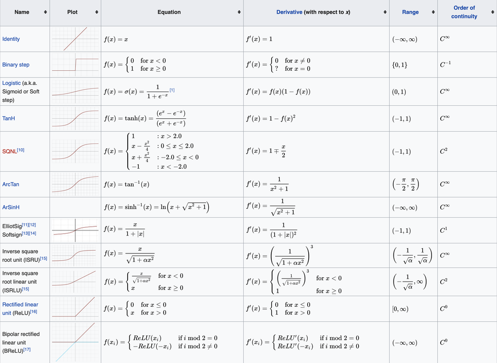

```python
Image("/Users/macbook/Desktop/2.png")
```

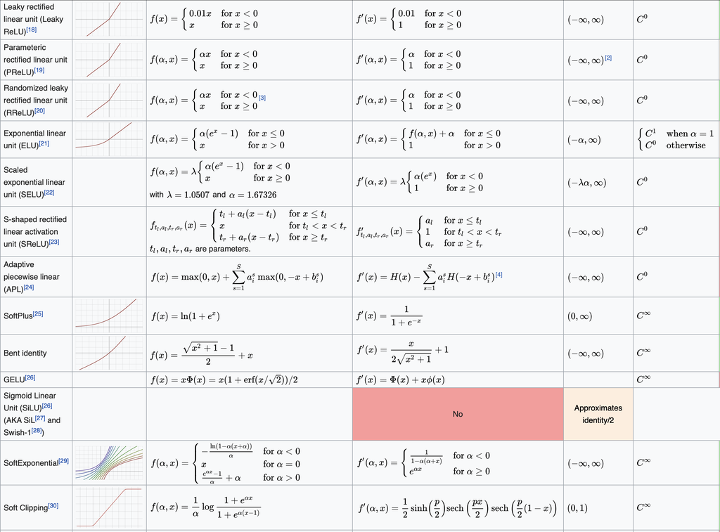

```python
Image("/Users/macbook/Desktop/3.png")
```

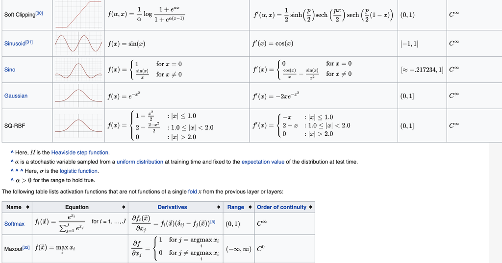

```python
Image("/Users/macbook/Desktop/4.png")
```

19) When and why should you normalize the data before training?

- The goal of normalization is to change the values of numeric columns in the dataset to a common scale, without distorting differences in the ranges of values. For machine learning, every dataset does not require normalization. It is required only when features have different ranges.

20) How do the following techniques prevent overfitting?

**Data augmentation**

21) Learning rate decay

- Learning rate schedules seek to adjust the learning rate during training by reducing the learning rate according to a pre-defined schedule. Common learning rate schedules include time-based decay, step decay and exponential decay.
- Let's use the time decay function. This updates the learning rate by the expression below:  
  $new_{LR} = \frac{current_{LR}}{(1 + decay-rate * epoch_num)}$

22) What is fully convolutional neural network?

- Fully convolutional indicates that the neural network is composed of convolutional layers without any fully-connected layers or MLP usually found at the end of the network. A CNN with fully connected layers is just as end-to-end learnable as a fully convolutional one. The main difference is that the fully convolutional net is learning filters every where. Even the decision-making layers at the end of the network are filters.
  - A fully convolutional net tries to learn representations and make decisions based on local spatial input. Appending a fully connected layer enables the network to learn something using global information where the spatial arrangement of the input falls away and need not apply.

24) Result of Convolution? http://www.songho.ca/dsp/convolution/convolution2d_example.html

25) Max: (15 8)/(8, 17) Average: (10, 5)/(5, 8)

26) What does receptive field mean?

- The receptive field is defined as the region in the input space that a particular CNN’s feature is looking at (i.e. be affected by). A receptive field of a feature can be described by its center location and its size. (Edit later) However, not all pixels in a receptive field is equally important to its corresponding CNN’s feature.

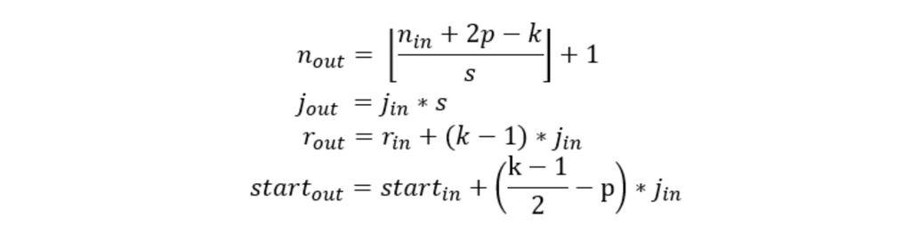

```python
Image("/Users/macbook/Desktop/7.png")
```

27) Where are the weaknesses of gradient descent?

28) What does momentum mean in optimisation algorithms?

- Momentum, which is a moving average of our gradients. We then use it to update the weight of the network. This could written as follows:

```python
Image(url='https://blog.paperspace.com/content/images/2018/06/momentum.png')
```

[figure not shown]

29) What does adaptive learning rate (e.g. in Adagrad, RMSProp) mean in optimisation algorithms?

- Momentum:While SGD has problems with data having steep curves in one direction of the gradient, Momentum circumvents that by adding the update vector of the time step before multiplying it with a γ, usually around 0.9 (1).
- Nesterov: adds a guess of the next step, in the form of the term γ*v_t−1
- Adagrad: Adagrad adapts its learning rate η during its run-time and it updates its parameters θi separately during each time step t . It has to do that, since η adapts for every θi on its own.

30) Ensemble modeling

- Ensemble modeling is a process where multiple diverse models are created to predict an outcome, either by using many different modeling algorithms or using different training data sets. The ensemble model then aggregates the prediction of each base model and results in once final prediction for the unseen data.
  - The motivation for using ensemble models is to reduce the generalization error of the prediction.

31) Train/Validation/Test

- Training: this data set is used to adjust the weights on the neural network.
- Validation: this data set is used to minimize overfitting.
- Test: this data set is used only for testing the final solution

32) What does transfer learning mean? How and why do we use it?

- Transfer learning is a machine learning method where a model developed for a task is reused as the starting point for a model on a second task.
  - Two common approaches are as follows: -Develop Model Approach -Pre-trained Model Approach
- It is common to perform transfer learning with natural language processing problems that use text as input or output. For these types of problems, a word embedding is used that is a mapping of words to a high-dimensional continuous vector space where different words with a similar meaning have a similar vector representation. Efficient algorithms exist to learn these distributed word representations and it is common for research organizations to release pre-trained models trained on very large corpa of text documents under a permissive license.

33) Define the convolutional layer (with formula).

```python
Image(url='https://sds-platform-private.s3-us-east-2.amazonaws.com/uploads/70_blog_image_1.png')
```

[figure not shown]

34) What is inception module?

- Allow for more efficient computation and deeper Networks through a dimensionality reduction with stacked 1×1 convolutions.
  - The solution, in short, is to take multiple kernel filter sizes within the CNN, and rather than stacking them sequentially, ordering them to operate on the same level.

35) Residual blocks

- In a network with residual blocks, each layer feeds into the next layer and directly into the layers about 2–3 hops away.
  - You can skip the training of few layers using skip-connections or residual connections.

36) -

37) What is bag of words? Should it be used with sequential data, why?

- The bag-of-words model is a simplifying representation used in natural language processing and information retrieval (IR). In this model, a text (such as a sentence or a document) is represented as the bag (multiset) of its words, disregarding grammar and even word order but keeping multiplicity. The bag-of-words model has also been used for computer vision. The bag-of-words model is commonly used in methods of document classification where the (frequency of) occurrence of each word is used as a feature for training a classifier.

39) What is (truncate) backpropagation through time?

- We can summarize the algorithm as follows:
  - Present a sequence of timesteps of input and output pairs to the network.
  - Unroll the network then calculate and accumulate errors across each timestep.
  - Roll-up the network and update weights.
  - Repeat.
- BPTT can be computationally expensive as the number of timesteps increases.

40) What is the vanishing/exploding gradient problem? a.How can it be prevented?

- In such methods, each of the neural network's weights receives an update proportional to the partial derivative of the error function with respect to the current weight in each iteration of training. The problem is that in some cases, the gradient will be vanishingly small, effectively preventing the weight from changing its value.
- exploding gradients can result in an unstable network that at best cannot learn from the training data and at worst results in NaN weight values that can no longer be updated. How can it be prevented?
  1. Re-Design the Network Model
  2. Use Long Short-Term Memory Networks
  3. Use Gradient Clipping
  4. Use Weight Regularization

41) -

42) What is K-means clustering?

- Kmeans algorithm is an iterative algorithm that tries to partition the dataset into Kpre-defined distinct non-overlapping subgroups (clusters) where each data point belongs to only one group.
  1. Specify number of clusters K.
  2. Initialize centroids by first shuffling the dataset and then randomly selecting K data points for the centroids without replacement.
  3. Keep iterating until there is no change to the centroids. i.e assignment of data points to clusters isn’t changing.
  - Compute the sum of the squared distance between data points and all centroids.
  - Assign each data point to the closest cluster (centroid).
  - Compute the centroids for the clusters by taking the average of the all data points that belong to each cluster.

43) What is PCA?

- Principal component analysis (PCA) is a statistical procedure that uses an orthogonal transformation to convert a set of observations of possibly correlated variables (entities each of which takes on various numerical values) into a set of values of linearly uncorrelated variables called principal components. This transformation is defined in such a way that the first principal component has the largest possible variance (that is, accounts for as much of the variability in the data as possible), and each succeeding component in turn has the highest variance possible under the constraint that it is orthogonal to the preceding components. The resulting vectors (each being a linear combination of the variables and containing n observations) are an uncorrelated orthogonal basis set. PCA is sensitive to the relative scaling of the original variables.

44) What is an autoencoder? a.Denoising AE b.Sparse AE

- An autoencoder is a type of artificial neural network used to learn efficient data codings in an unsupervised manner.
  - Denoising autoencoders are an extension of the basic autoencoder, and represent a stochastic version of it
  - A sparse autoencoder is simply an autoencoder whose training criterion involves a sparsity penalty

45) What does the latent variable means?

- Variables that are not directly observed but are rather inferred (through a mathematical model) from other variables that are observed (directly measured). Mathematical models that aim to explain observed variables in terms of latent variables are called latent variable models. One advantage of using latent variables is that they can serve to reduce the dimensionality of data

46) Define the KL divergence!

- is a measure of how one probability distribution is different from a second, reference probability distribution. Applications include characterizing the relative (Shannon) entropy in information systems, randomness in continuous time-series, and information gain when comparing statistical models of inference

47) -

48) What is a variational autoencoder?

- VAE is an autoencoder whose encodings distribution is regularised during the training in order to ensure that its latent space has good properties allowing us to generate some new data. Instead of encoding an input as a single point, we encode it as a distribution over the latent space. The model is then trained as follows:
  1. first, the input is encoded as distribution over the latent space
  2. second, a point from the latent space is sampled from that distribution
  3. third, the sampled point is decoded and the reconstruction error can be computed
  4. finally, the reconstruction error is backpropagated through the network

49) What is a generative adversarial network?

- (this technique learns to generate new data with the same statistics as the training set. )
- Typically, the generative network learns to map from a latent space to a data distribution of interest, while the discriminative network distinguishes candidates produced by the generator from the true data distribution. The generative network's training objective is to increase the error rate of the discriminative network (i.e., "fool" the discriminator network by producing novel candidates that the discriminator thinks are not synthesized (are part of the true data distribution))

50)

- Normalize 1D array to interval [0, 1]:
  - b = (a - np.min(a))/np.ptp(a)
- Set each negative value of an array to zero:
  - a = a.clip(min=0)
- Calculate the (euclidean) length of each row:
  - np.hypot(*(points - single_point).T) / def distance(v1, v2):return np.sqrt(np.sum((v1 - v2) ** 2))
- Calculate the predicted class for a set of probabilities:
  1. prob = [[0.1, 0.5, 0.4], [0., 0.1, 0.9], [0.2, 0.6, 0.2]]
  2. [np.argmax(sub_list) for sub_list in prob]